# 선형회귀(LinearRegression) 실습- 보스턴 주택 가격 예측

## (1) 라이브러리/모듈 import

```python
import numpy as np
import matplotlib.pyplot as plt
import pandas as pd
import seaborn as sns

from sklearn.datasets import load_boston
from sklearn.model_selection import train_test_split

import warnings
warnings.filterwarnings('ignore')
```

## (2) 데이타셋 로드

```python
boston = load_boston()
```

```python
boston
```

```python
boston.data
```

```python
boston.feature_names
```

[Features]

- CRIM: 지역별 범죄 발생률
- ZN: 25,000평방피트를 초과하는 거주 지역의 비율
- INDUS: 비상업 지역 넓이 비율
- CHAS: 찰스강에 대한 더미 변수(강의 경계에 위치한 경우는 1, 아니면 0)
- NOX: 일산화질소 농도
- RM: 거주할 수 있는 방 개수
- AGE: 1940년 이전에 건축된 소유자 거주 주택의 비율
- DIS: 5개 주요 고용센터까지의 가중 거리
- RAD: 고속도로 접근 용이도
- TAX: 10,000달러당 재산세율
- PTRATIO: 지역의 교사와 학생 수 비율 (Pupil-Teacher)
- B: 지역의 흑인 거주 비율
- LSTAT: 하위 계층의 비율
- MEDV: 본인 소유의 주택 가격(중앙값) (단위 $1,000)

```python
boston.target
```

```python
#boston.target_names
#왜 에러가 날까?
```

[Target]

- Price : 주택가격
- 각 feature를 이용 주택가격 예측
- Boston 데이터에 target_names는 왜 없었을까? (이산형데이터 VS 연속형데이터)

## (3) 데이타셋을 DataFrame으로 변환

```python
bostonDF = pd.DataFrame(data=boston.data , columns = boston.feature_names)
```

### (3.1) bostonDF에 'price'추가

```python
bostonDF['PRICE'] = boston.target
```

```python
bostonDF.shape
```

```python
bostonDF.head()
```

## (4) 8개의 주요 feature와 price간 산점도

### 1) 8개의 주요 feature 선정

```python
features = ['RM','ZN','INDUS','NOX','AGE','PTRATIO','LSTAT','RAD']
```

[Features]

- RM: 거주할 수 있는 방 개수
- ZN: 25,000평방피트를 초과하는 거주 지역의 비율
- INDUS: 비상업 지역 넓이 비율
- NOX: 일산화질소 농도
- AGE: 1940년 이전에 건축된 소유 주택의 비율
- PTRATIO: 지역의 교사와 학생 수 비율
- LSTAT: 하위 계층의 비율
- RAD: 고속도로 접근 용이도

### 2) 2행 4열의 subplots 설정

```python
fig, axs = plt.subplots(figsize=(16,8) ,nrows=2, ncols=4)
```

### 3) seaborn의 regplot 이용, 산점도와 선형 회귀 직선 함께 표현

```python
fig, axs = plt.subplots(figsize=(16,8) ,nrows=2, ncols=4)

sns.regplot(x=features[0], y='PRICE',data=bostonDF , ax=axs[0][0])
sns.regplot(x=features[1], y='PRICE',data=bostonDF , ax=axs[0][1])
sns.regplot(x=features[2], y='PRICE',data=bostonDF , ax=axs[0][2])
sns.regplot(x=features[3], y='PRICE',data=bostonDF , ax=axs[0][3])

sns.regplot(x=features[4], y='PRICE',data=bostonDF , ax=axs[1][0])
sns.regplot(x=features[5], y='PRICE',data=bostonDF , ax=axs[1][1])
sns.regplot(x=features[6], y='PRICE',data=bostonDF , ax=axs[1][2])
sns.regplot(x=features[7], y='PRICE',data=bostonDF , ax=axs[1][3])
```

[output not shown]

### 4) 학습과 테스트 데이터 세트로 분리하고 학습/예측/평가

```python
y_target = bostonDF['PRICE']
```

```python
X_data = bostonDF.drop(['PRICE'],axis=1,inplace=False)
```

```python
X_train , X_val , y_train , y_val = train_test_split(X_data , y_target ,test_size=0.3, random_state=156)
```

### estimator: Linear Regression

```python
from sklearn.linear_model import LinearRegression
```

```python
lr = LinearRegression()
```

- https://scikit-learn.org/stable/modules/generated/sklearn.linear_model.LinearRegression.html
- parameters, attributes, method 확인!

```python
lr.fit(X_train ,y_train )
```

```python
y_preds = lr.predict(X_val)
```

### 성능평가 - MSE, RMSE, R-Square

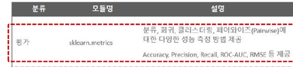

```python
from sklearn.metrics import mean_squared_error, r2_score
```

```python
mse = mean_squared_error(y_val, y_preds)
```

```python
rmse = np.sqrt(mse)
```

```python
print('MSE : {0:.3f} , RMSE : {1:.3F}'.format(mse , rmse))
```

- r2_score()

```python
r2=r2_score(y_val, y_preds)
```

```python
print('R-Square : {0:.3f}'.format(r2))
```

### 학습모델 확인

```python
print('절편 값:',lr.intercept_)
```

```python
print('회귀 계수값:', np.round(lr.coef_, 1))
```

```python
#print('회귀 계수값:', round(lr.coef_, 1)) - 왜 에러날까?
```

```python
lr.feature_names_in_
```

### 회귀 계수를 coeff에 pd.Series형태로 저장

```python
coeff = pd.Series(index=lr.feature_names_in_, data = np.round(lr.coef_,1))
```

```python
print(coeff)
```

### coeff를 큰 값 순으로 정렬

```python
coeff.sort_values(ascending=False)
```

```python
coeff.sort_values?
```